# Lecture 7-2: Introduction to model fitting / optimization

The goal of a model is to provide a simple low-dimensional summary of a dataset. E.g. instead of n data points (n-dimensional object) a vector of p parameters (p-dimensional, assuming that p<<n).

In this introduction we will focus on models that fit a curve to data.

There are two parts to such a model:

- a family of models that express a precise pattern that you want to capture. For example, the pattern might be a straight line, or a square root curve.

  You will express the model family is expressed as an equation like $y = a_1 + a_2 \cdot x$ or $y = a_1 + a_2 \cdot \sqrt x$.

  Here, x and y are known variables from your data, and a1 and a2 are parameters that can vary to capture different patterns.
- a fitted model by finding the model from the family that is the “closest” to your data. This takes the generic model family and makes it specific, like $y = 3 \cdot x + 7$ or $y = 9 \cdot \sqrt x + 2$.

Lets take a look at the simulated dataset sim:

It contains two continuous variables, x and y. Let’s plot them to see how they’re related:

```r
sim <- readRDS("sim.rds")

library(tidyverse)
```

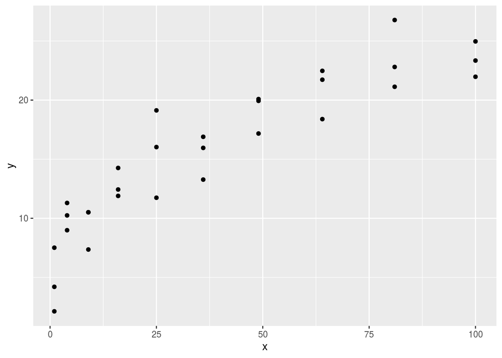

```r
ggplot(sim, aes(x, y)) +
  geom_point()
```

You can see a strong pattern in the data. Let’s use a model to capture that pattern and make it explicit.

We need to supply the basic form of the model.

In this case, the relationship looks concave. Let’s try our luck with $y = a_1 + a_2 \cdot \sqrt x$. Let’s start by getting a feel for what models from that family look like by randomly generating a few and overlaying them on the data.

Random parameter values:

```r
models <- data.frame(
  a1 = runif(250, -20, 40),
  a2 = runif(250, 0, 5)
)
```

Add them to the plot:

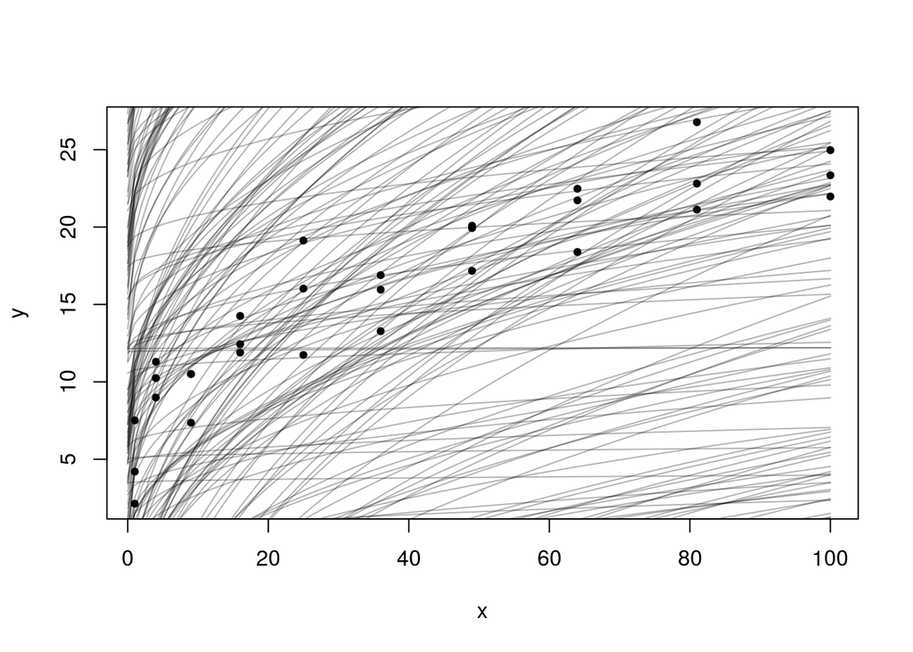

```r
plot(sim$x, sim$y, pch = 20, xlab = "x", ylab = "y")
for (i in 1:nrow(models)) {
  lines(0:100, models$a1[i] + models$a2[i] * sqrt(0:100), col = rgb(0, 0, 0, 0.3))
}
```

There are 250 models on this plot, but a lot are really bad!

We need to find the good models by making precise our intuition that a good model is “close” to the data. We need a way to quantify the distance between the data and a model. Then we can fit the model by finding the value of $a_1$ and $a_2$ that generate the model with the smallest distance from this data.

One easy place to start is to find the vertical distance between each point and the model.

This distance is the difference between the y value given by the model (the prediction), and the actual y value in the data (the response).

To compute this distance, we first turn our model family into an R function. This takes the model parameters and the data as inputs, and gives values predicted by the model as output:

```r
model1 <- function(a1, a2, data) {
  return( a1 + a2 * sqrt(data$x) )
}
```

Try it:

```r
model1(7, 1.5, sim)
```

```
##  [1]  8.5  8.5  8.5 10.0 10.0 10.0 11.5 11.5 11.5 13.0 13.0 13.0 14.5 14.5
## [15] 14.5 16.0 16.0 16.0 17.5 17.5 17.5 19.0 19.0 19.0 20.5 20.5 20.5 22.0
## [29] 22.0 22.0
```

One common way to do this in statistics to use the “root-mean-squared deviation”. We compute the difference between actual and predicted, square them, average them, and the take the square root.

```r
measure_distance1 <- function(a1, a2, data) {
  diff <- data$y - model1(a1, a2, data)
  return( sqrt(mean(diff ^ 2)) )
}

measure_distance1(7, 1.5, sim)
```

```
## [1] 2.665212
```

We can add a column that measures the distance for all the points using `mapply` (which is an `apply` family function that iterates over several parameters at a time):

```r
models$dist <- mapply(measure_distance1, a1 = models$a1, a2 = models$a2, MoreArgs = list(data = sim))
```

Or equivalently using `purrr::map2dbl()`

```r
models <- models %>%
  mutate(dist2 = purrr::map2_dbl(a1, a2, .f = measure_distance1, data = sim))
head(models)
```

```
##           a1         a2      dist     dist2
## 1  30.507588 3.38775006 33.921042 33.921042
## 2  -8.936912 0.05381147 24.908730 24.908730
## 3   8.051189 1.11781795  3.664000  3.664000
## 4   1.812198 2.18746937  2.727717  2.727717
## 5   5.633377 3.94829803 13.210175 13.210175
## 6 -12.586622 3.52831284  9.897137  9.897137
```

Are the results the same?

```r
all.equal(models$dist, models$dist2)
```

```
## [1] TRUE
```

Since they are, we can omit one of the duplicate columns:

```r
models$dist2 <- NULL
```

Next, let’s overlay the 10 best models on to the data. Color the models by -dist:

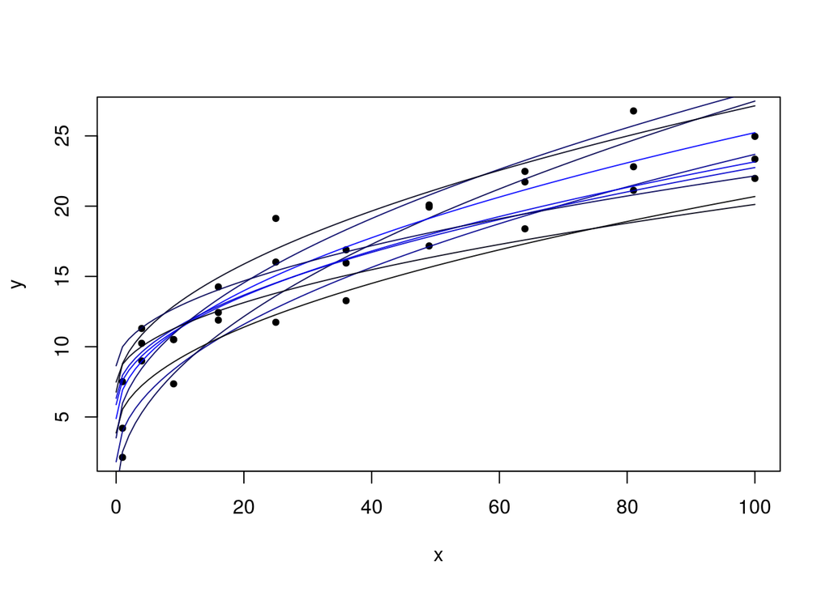

```r
n_top <- 10
best_models <- filter(models, rank(dist) <= n_top)
scale_best_models <- ( (best_models$dist - min(best_models$dist) ) / ( max(best_models$dist) - min(best_models$dist) )  )

plot(sim$x, sim$y, pch = 20, xlab = "x", ylab = "y")
for (i in 1:n_top) {
  lines(0:100, best_models$a1[i] + best_models$a2[i] * sqrt(0:100), col = rgb(0, 0, 1 - scale_best_models[i], 0.9))
}
```

We can also think about these models as observations, and visualizing with a scatterplot of a1 vs a2, again colored by -dist. We can no longer directly see how the model compares to the data, but we can see many models at once. Again, I’ve highlighted the 10 best models, this time by drawing red circles underneath them.

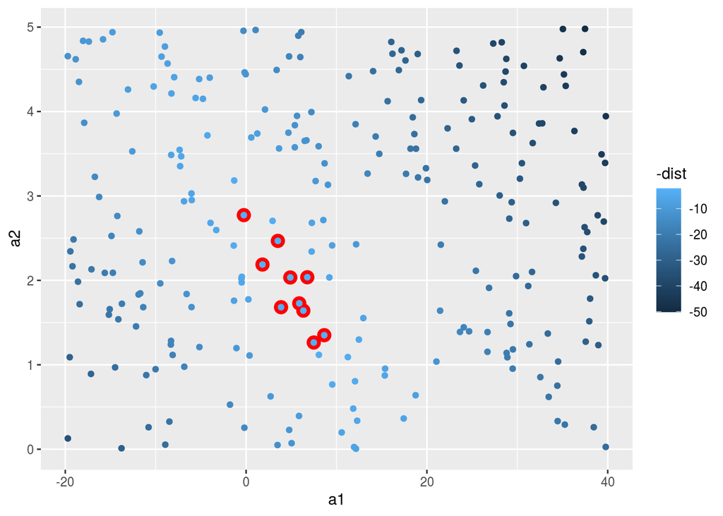

```r
ggplot(models, aes(a1, a2)) +
  geom_point(data = filter(models, rank(dist) <= 10), size = 4, colour = "red") +
  geom_point(aes(colour = -dist))
```

Instead of trying lots of random models, we could be more systematic and generate an evenly spaced grid of points (this is called a grid search).

We can pick the parameters of the grid roughly by looking at where the best models were in the plot above.

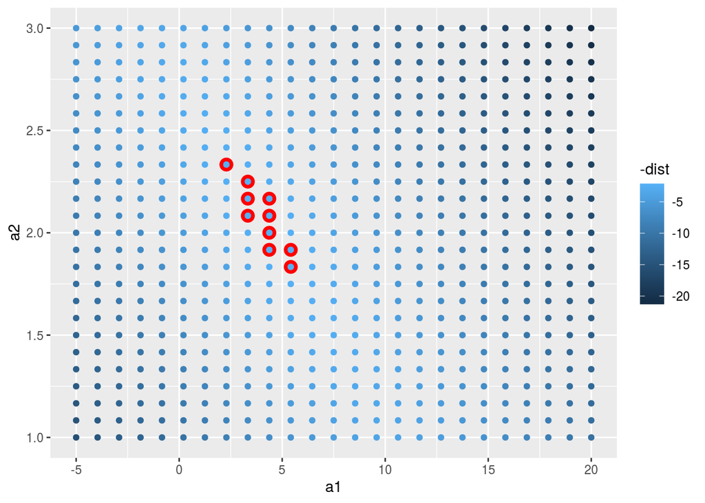

```r
grid <- expand.grid(
  a1 = seq(-5, 20, length = 25),
  a2 = seq(1, 3, length = 25)
) %>%
  mutate(dist = purrr::map2_dbl(a1, a2, .f = measure_distance1, data = sim))

ggplot(data = grid, aes(a1, a2)) +
  geom_point(data = filter(grid, rank(dist) <= 10), size = 4, colour = "red") +
  geom_point(aes(colour = -dist))
```

When you overlay the best 10 models back on the original data, they all look pretty good:

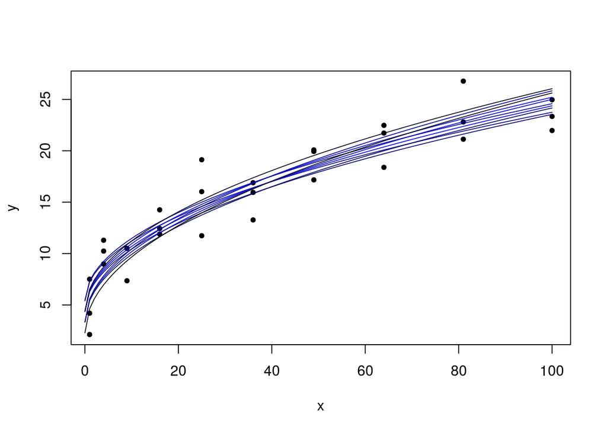

```r
n_top <- 10
best_models <- filter(grid, rank(dist) <= n_top)
scale_best_models <- ( (best_models$dist - min(best_models$dist) ) / ( max(best_models$dist) - min(best_models$dist) )  )

plot(sim$x, sim$y, pch = 20, xlab = "x", ylab = "y")
for (i in 1:n_top) {
  lines(0:100, best_models$a1[i] + best_models$a2[i] * sqrt(0:100), col = rgb(0, 0, 1 - scale_best_models[i], 0.9))
}
```

We could imagine iteratively making the grid finer and finer until you narrowed in on the best model. But there’s a better way to tackle that problem: a numerical minimization tool called Newton-Raphson search.

The intuition of Newton-Raphson is pretty simple: you pick a starting point and look around for the steepest slope. You then ski down that slope a little way, and then repeat again and again, until you can’t go any lower. In R, we can do that with optim():

```r
measure_distance1_helper <- function(a, data) {
  return( measure_distance1(a[1], a[2], data) )
}

best1 <- optim(c(0, 0), measure_distance1_helper, data = sim)
best1$par
```

```
## [1] 4.222248 2.051204
```

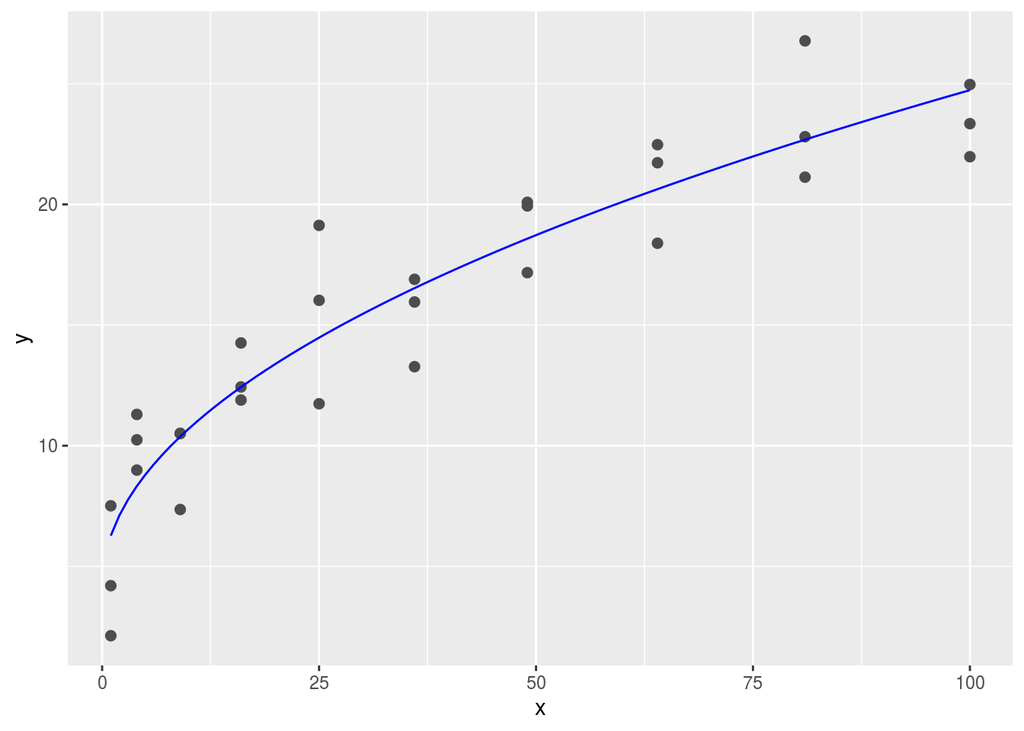

```r
ggplot(sim, aes(x, y)) +
  geom_point(size = 2, colour = "grey30") +
  geom_function(fun = function(x) best1$par[1] + best1$par[2] * sqrt(x), color = "blue")
```

If you have a function that defines the distance between a model and a dataset, an algorithm that can minimize that distance by modifying the parameters of the model, you can find the best model.

This approach will work for any family of models that you can write an equation for.

# Exercises

Repeat the optim step for the family of models $a_1 + a_2 \cdot x ^ {a_3}$ and the same data `sim`. Which is a better fit?

Is the optimizer sensitive to initial values?

Try a different distance measure for both methods: absolute difference

One of the two models we tried is actually … Show it!